[output not shown]

## **Week 4 Homework Assignment**

**This assignment helps understanding binomial regression**

The assignment is due on the day of the next class at 11:59 pm.

This assignment is individual

**1. Select an area of application, for example, biomedical studies, engineering, marketing, etc.**

I am interested in exploring different marketing data set for application of a binomial regression.

**2. For the selected area of application postulate a problem that could be solved using binomial regression.** **Think of the two versions of the experiment design: with prospective and retrospective sampling.** **It is recommended to postulate the problem with two predictors.**

I wanted to use data from within the marketing industry. I found a competition on kaggle that had click-through data, however through further investication I found that this data was a bit too complicated for this assignment and that I could not effectively condense the 22 independent variables down to only two.

As an alternative, I decided to take the same approach but simulate my own data. Therefore I created a sceario in which we are measuring whether or not a user clicked on a link and are capturing two independent varaibles: the user’s sex (M or F) and the hour of the day that the user was exposed to the link (1pm through 5pm).

**Prospective experimental design:**

Designate a random group of people, half male and half female, and split them into five groups randomly. Then have each group browse the internet (or the target website) during a different times of the day, splitting the groups across each of the five hours (1pm - 5pm). Then record whether or not each person clicks on the link that you are intending to measure.

**Retrospective experimental design:**

Access the click stream database to the target website. Gather the the following historical data between 1pm and 5pm: the website visitor’s sex, the time the visited the site, and whether or not they clicked on the link that you want to measure.

**3. Find or simulate data for the model.**

Below is the setup of the simulated data. Please note that this simulated data is over engineered and therefore produces a very strong model, but the learnings from the exercise still apply.

```r
library(faraway)
library(plyr)
#initialize vectors
click <- numeric()
hour <- numeric()
count1 <- 0
count2 <- 0
#creating the data
for (i in c(5,7,18,45,60)){
  count1 <- count1+1
  p <- i*.01
  d <- rbinom(100,1,p)
  click <- c(click,d)
  hour <- c(hour,rep(count1,100))
}
for (i in c(10,11,23,50,65)){
  count2 <- count2+1
  p <- i*.01
  d <- rbinom(100,1,p)
  click <- c(click,d)
  hour <- c(hour,rep(count2,100))
}
sex <- c(rep("M",500),rep("F",500))

in.data <- data.frame(click,hour,sex)

table.data <- ddply(in.data, .(hour, sex), summarise, clicks=sum(click==1), noclicks=sum(click==0))
table.data
```

```
##    hour sex clicks noclicks
## 1     1   F     10       90
## 2     1   M      7       93
## 3     2   F      9       91
## 4     2   M      5       95
## 5     3   F     19       81
## 6     3   M     19       81
## 7     4   F     52       48
## 8     4   M     45       55
## 9     5   F     58       42
## 10    5   M     59       41
```

**4. Analize the use of the three different link functions and compare them to each other.**

The logit is the most common transformation. Since probabilities fall between 0 and 1, a transformation is necessary so that we do not have to put considerable constraints on our coeffificents and independent variables. Hence the initial odds transformation which changes the range to 0 to infinity. And then finally the log odds transforms the range to negative infinity to infinity, allowing for the model to takes its most flexible and fitting form.

The probit function is necessary to transform the data using the same logic as above, but probit models are more tractable in some situations than logit models (e.g. in a Bayesian setting in which normally distributed prior distributions are placed on the parameters)

**5. Conduct the fit of binomial regression model using glm() with family=binomial.**

```r
#creating the 3 models that differ by link fn

#logit
modl<-glm(formula = cbind(clicks,noclicks) ~ hour + sex,family=binomial,data=table.data)
#probit
modp<-glm(formula = cbind(clicks,noclicks) ~ hour + sex,family=binomial(link=probit),data=table.data)
#complementary log log
modc<-glm(formula = cbind(clicks,noclicks) ~ hour + sex,family=binomial(link=cloglog),data=table.data)

modl
```

```
##
## Call:  glm(formula = cbind(clicks, noclicks) ~ hour + sex, family = binomial,
##     data = table.data)
##
## Coefficients:
## (Intercept)         hour         sexM
##     -3.6555       0.8397      -0.1616
##
## Degrees of Freedom: 9 Total (i.e. Null);  7 Residual
## Null Deviance:       233.6
## Residual Deviance: 17.12     AIC: 67.64
```

```r
modp
```

```
##
## Call:  glm(formula = cbind(clicks, noclicks) ~ hour + sex, family = binomial(link = probit),
##     data = table.data)
##
## Coefficients:
## (Intercept)         hour         sexM
##     -2.0984       0.4805      -0.1008
##
## Degrees of Freedom: 9 Total (i.e. Null);  7 Residual
## Null Deviance:       233.6
## Residual Deviance: 19.26     AIC: 69.77
```

```r
modc
```

```
##
## Call:  glm(formula = cbind(clicks, noclicks) ~ hour + sex, family = binomial(link = cloglog),
##     data = table.data)
##
## Coefficients:
## (Intercept)         hour         sexM
##     -3.3954       0.6853      -0.1078
##
## Degrees of Freedom: 9 Total (i.e. Null);  7 Residual
## Null Deviance:       233.6
## Residual Deviance: 18.77     AIC: 69.28
```

```r
fit.check <- cbind(fitted(modl),fitted(modp),fitted(modc))
summary(fit.check)
```

```
##        V1                V2                V3
##  Min.   :0.04846   Min.   :0.04285   Min.   :0.05798
##  1st Qu.:0.10954   1st Qu.:0.11282   1st Qu.:0.11474
##  Median :0.22873   Median :0.24002   Median :0.22002
##  Mean   :0.28300   Mean   :0.28325   Mean   :0.28236
##  3rd Qu.:0.41660   3rd Qu.:0.42028   3rd Qu.:0.39727
##  Max.   :0.63249   Max.   :0.61957   Max.   :0.64355
```

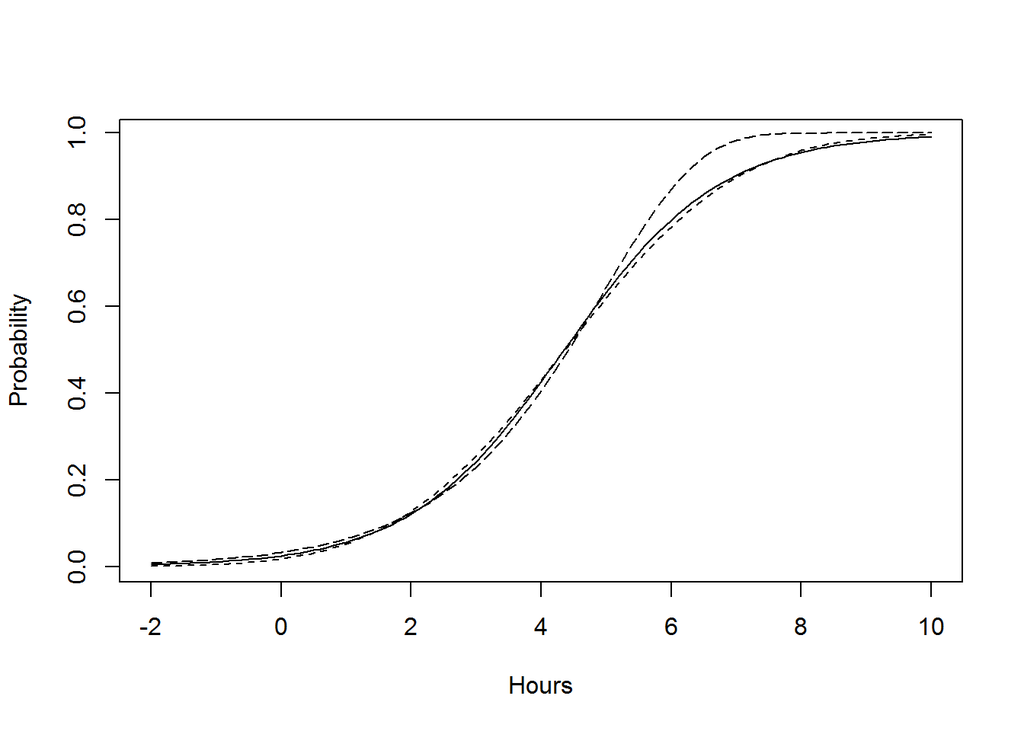

```r
x<-seq(-2,10,.1)
pl<-ilogit(modl$coef[1]+modl$coef[2]*x)
pp<-pnorm(modp$coef[1]+modp$coef[2]*x)
pc<-1-exp(-exp((modc$coef[1]+modc$coef[2]*x)))
plot(x,pl,type="l",ylab="Probability",xlab="Hours")
lines(x,pp,lty=2)
lines(x,pc,lty=5)
```

**6. Describe the problem, all steps of obtaining solution and conclusions about the results.**

The problem was that we want to understand the impact on sex and time of day on whether or not a person visiting our website will click on a certain link (ex: a link that leads to the “products for sale” page).

```r
exp(0.9252)
```

```
## [1] 2.522373
```

```r
exp(-0.4508)
```

```
## [1] 0.6371183
```